# HRSPNet: what changed since last week

The full model, the changes from the musical predictors, and the two new layers

Dmitrii Mukhutdinov

2026-10-12

## HRSPNet: the full model

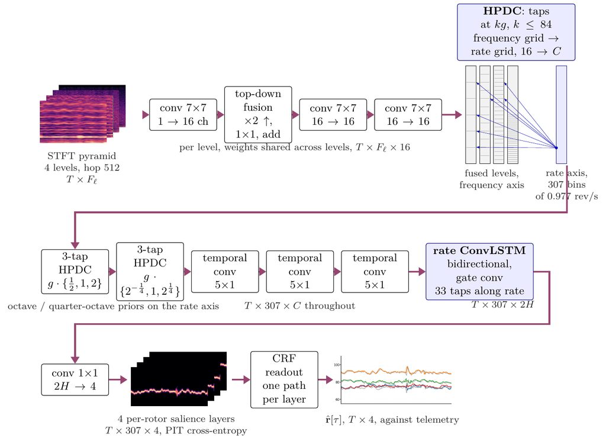

## Where we were: HPPNet-L2

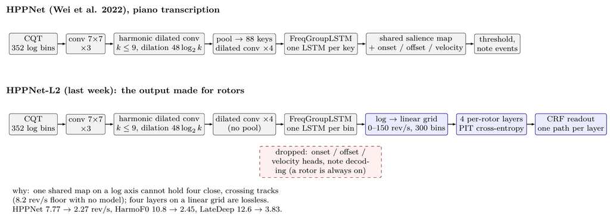

## Change 1: the front end — why not stay with the CQT

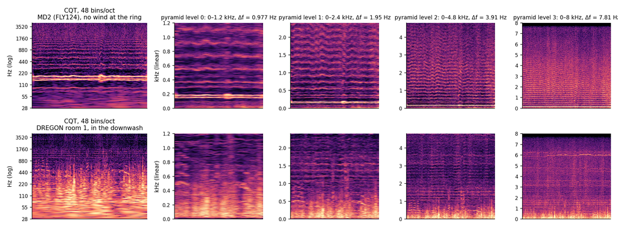

On MD2 the CQT is in its element: no wind at the ring, and the low orders carry the information, where the CQT’s long windows resolve the blade-passing lines best. On DREGON the microphones sit in the downwash: the low band is buried in flow noise and the usable lines are the high motor orders (the bright $k \approx 70$ line near 6 kHz), which the CQT’s 15 ms windows smear. The pyramid keeps 1 Hz bins at the bottom and still resolves the top.

## Change 1: HPDC on the pyramid, and what it reads

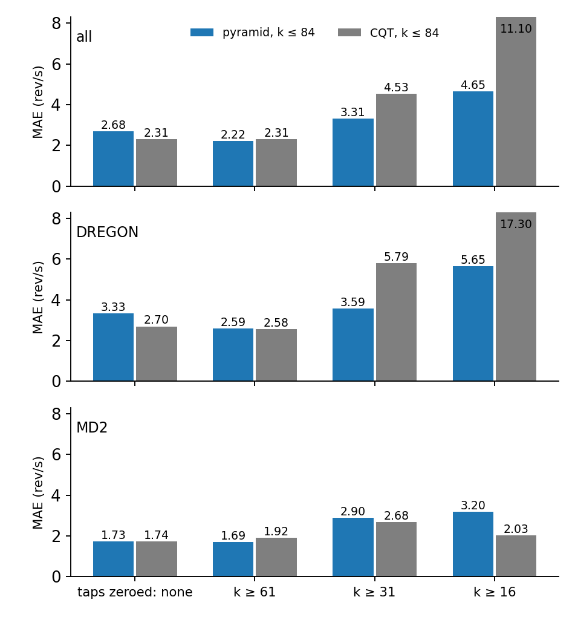

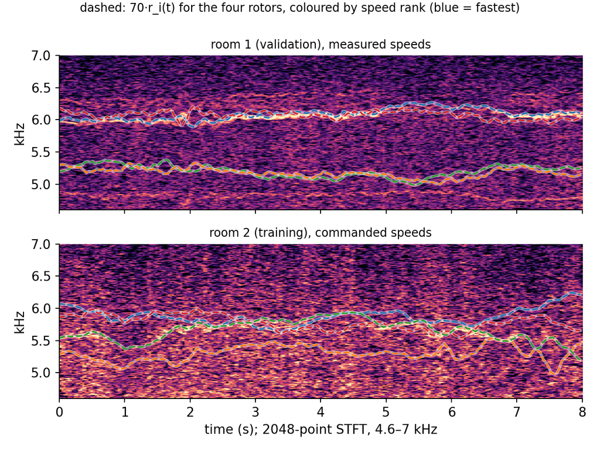

Why: the bright $k \approx 70$ motor line belongs to the fastest rotor in room 1 and to the third fastest in room 2, so the per-rotor layers learn it as an identity cue and point at the wrong rotor in validation; room 2’s commanded speeds also sit above the line (1–3 %, 10+ bins at 7.8 Hz). A data problem; HRSPNet reads taps below 4.8 kHz for now.

## Change 2: a recurrence that follows the rotor

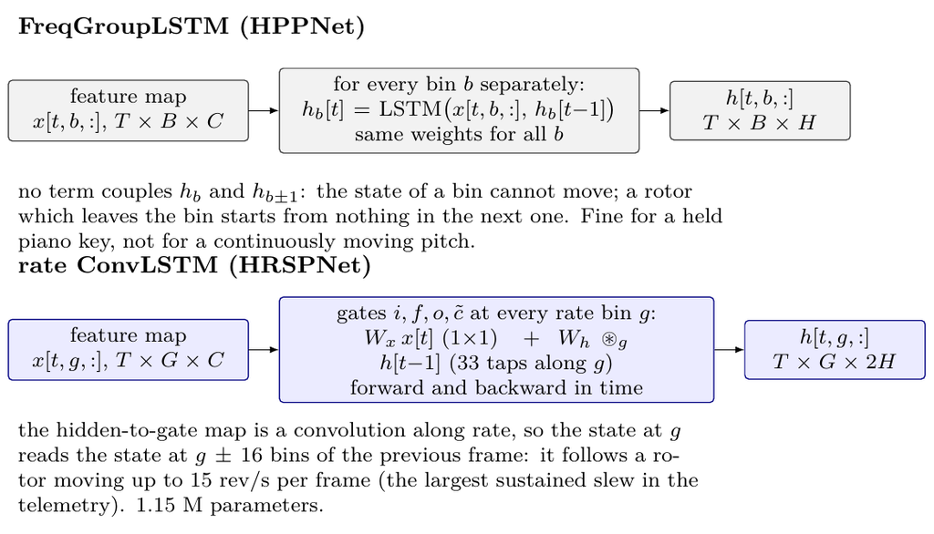

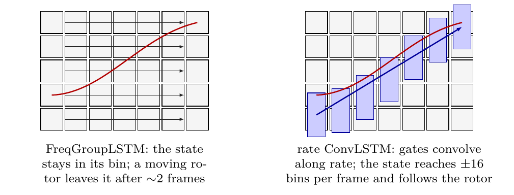

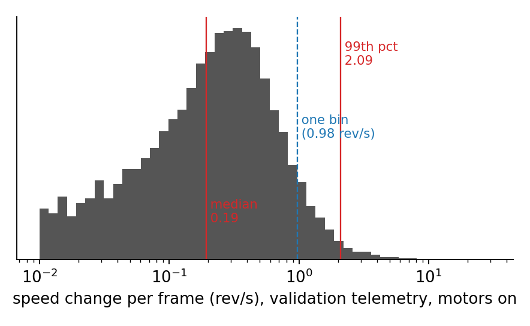

## Where it stands: real-data training, no synthetic pretraining

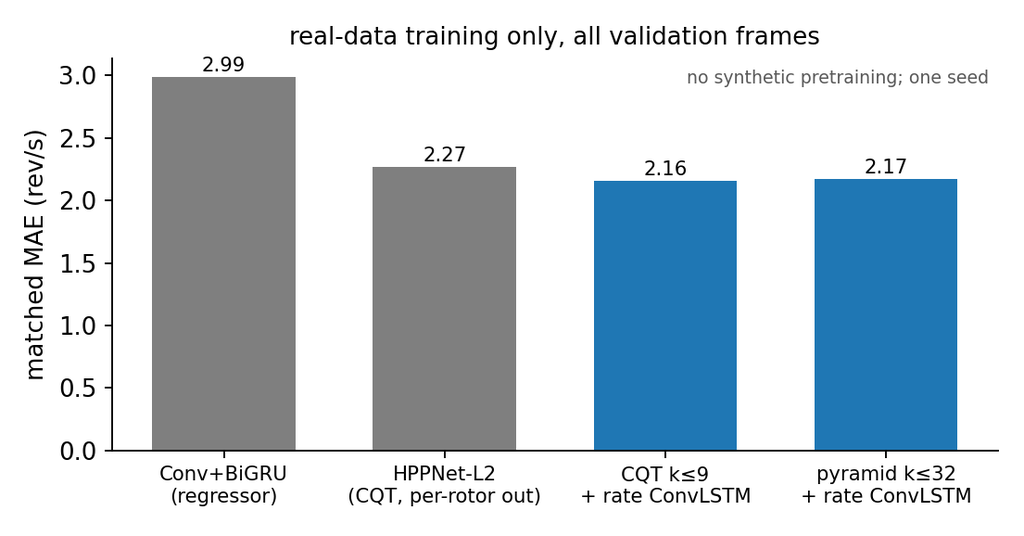

## Pretraining on the generative model: status

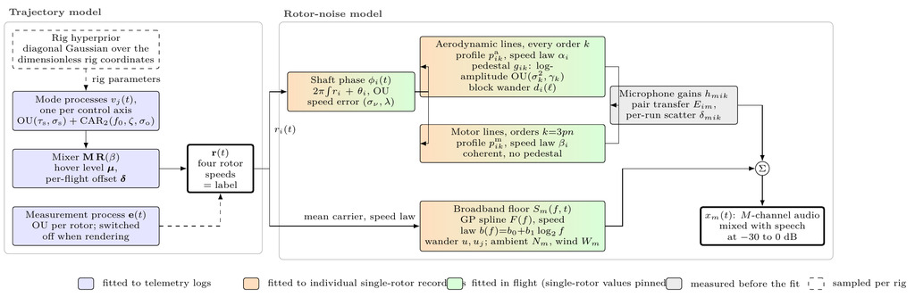

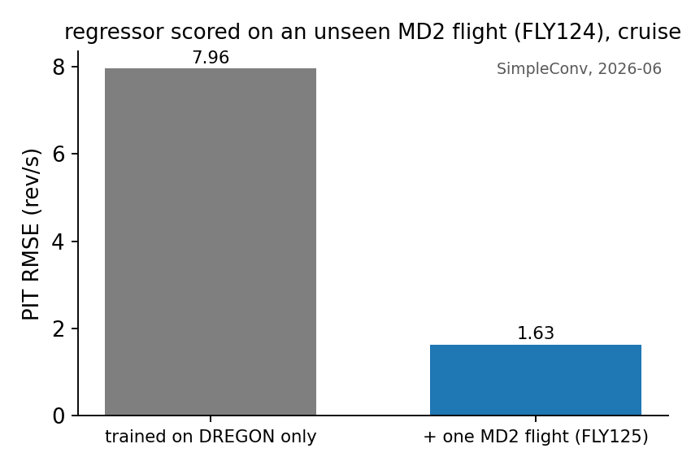

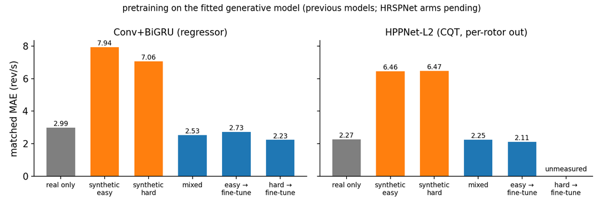

## Next

1. **HRSPNet with the full harmonic set** ($k \le 84$, taps below 4.8 kHz) + rate ConvLSTM — the headline cell; the ConvLSTM arms above still use $k \le 32$ / $k \le 9$.
2. **Pretraining arms for HRSPNet**: easy / hard / mixed / fine-tuned, plus the two held-out views (synthetic rigs, unseen drone after fine-tuning).
3. **Unified-protocol rerun** of every paper row (2 s chunks, same panel): output adaptation × 4 models, the HPPNet → HRSPNet grid, regressors.
4. **Cross-drone table**: DREGON-only and MD2-only training for HRSPNet and the regressor.
5. Paper draft restructured around the method; pending results sit behind `\wip{}`.